# Auxiliar 09 - Análisis de formas, Descriptores y Análisis espectral

### CC5513 - Procesamiento Geométrico y Análisis de Formas

## Objetivo/Contexto

En este auxiliar, veremos rápidamente varios temas de anális de formas. Nos centraremos en revisar varios archivos del repositorio del curso, con algunas variaciones para ilustrar conceptos.

## Descriptores

Nos permiten mantener representaciones de determinadas características de los objetos. Es posible que queramos representar el objeto completo, o bien localmente sus propiedades.

### Un descriptor sencillo es utilizar los eigenvalues del laplaciano

Sabemos que el operador de Laplace-Beltrami es invariante a las isometrías, por lo que describir un objeto utilizando sus propiedades resultaría en descriptores similares para objetos similares. Para esto, podemos utilizar por ejemplo los eigenvalues.

`shapeDNA.py`:

- Calculamos la matriz laplaciana
- Calculamos eigenvalues a partir de ella

Si bien para cada objeto tenemos $n$ valores propios, podemos visualizarlos todos en un mismo gráfico con una curva. Así, podemos comparar los descriptores para distintos objetos.

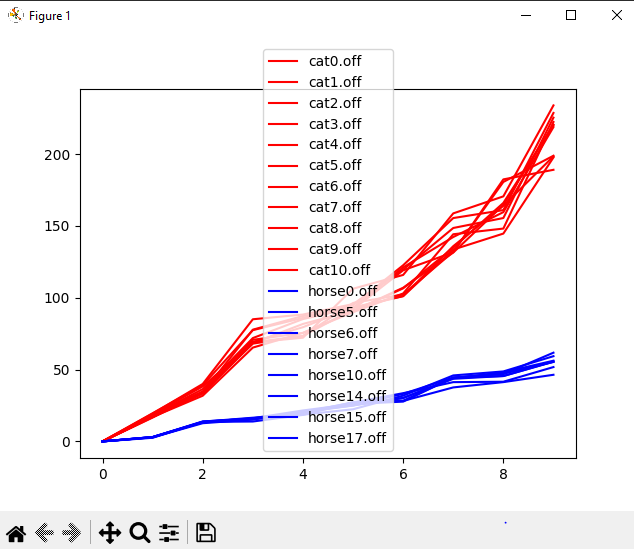

### Heat Kernel Signature

También es posible ver cómo se distribuye el calor en el Manifold, utilizando el laplaciano. Esta es una forma de describir los objetos donde tendremos información de, para cada vértice y dado un tiempo t, su valor. Podemos imaginarlo como cuanto calor permanece en cada vértice luego de un tiempo $t$.

Veamos `feature_point_hks.py`.

Primero, computamos el HKS para un solo tiempo. Esto significa que nuestro descriptor tendrá un valor de información para cada uno de los vértices. Podemos utilizar esta información para extraer puntos de interés, por ejemplo aquellos puntos donde el proceso de difusión de calor acumuló más cantidad.

Podemos determinar fácilmente estos vértices, pues basta comparar el descriptor de cada vértice con el de sus vecinos.

Pueden probar ir variando en qué t calculamos las características. La siguiente imagen ilustra el caso con $t=0.001$.

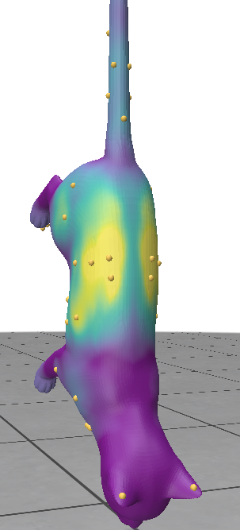

Por supuesto, podemos describir un periodo de tiempo amplio con este descriptor, no es necesario quedarse con un solo $t$. El incluir muchos valores de $t$ nos permite caracterizar de manera más completa el proceso de difusión de calor.

En `heat_kernel_signature.py`, calculamos 100 valores de $t$, y graficamos estos 100 valores para 4 vértices del objeto.

Para visualizar el descriptor para todos los vértices, podemos añadir una cantidad escalar por cada dimensión del hks. Esto lo podemos hacer a partir del código de `heat_kernel_signature.py`.

```
...
file = "cat0.off"
hks = compute_hks(file, args)

mesh = openmesh.read_trimesh(file)
points = mesh.points()

ps.init()
ps_mesh = ps.register_surface_mesh("mesh", mesh.points(), mesh.face_vertex_indices())

for i in range(10):
  ps_mesh.add_scalar_quantity(f"distances {i:0d}", hks[:, i])
ps.show()
```

### Segmentación con Global Point Signature

(Global Point Signature): $$ \left( \frac{\phi(\vec{p_1})}{\lambda_1}, \frac{\phi(\vec{p_2})}{\lambda_2}, ..., \frac{\phi(\vec{p_m})}{\lambda_m} \right) $$

Algo que se puede hacer con el descriptor GPS es utilizar las descripciones de los vértices para segmentar los objetos. Podemos considerar las descripciones para cada vértice como elementos m-dimensionales (ya que este tipo de descriptores utilizan $m$ valores y vectores propios) y agruparlos viendo qué vertices contienen propiedades similares. Un simple proceso de clustering basta para esto, como podemos experimentar en `gps.py`.

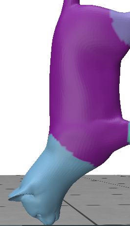